# Integració i Neteja del fitxer test.csv

ANNA SERENA LATRE/XAVIER JORDÀ MURRIA

19 maig de 2019

La dimensió del fitxer test és de 418 files i 11 columnes.

```r
# test dataset dimension.
dim(test)
```

```
## [1] 418  11
```

Els noms de les onze variables són:

```r
# test dataset variable names.
names(test)
```

```
##  [1] "PassengerId" "Pclass"      "Name"        "Sex"         "Age"
##  [6] "SibSp"       "Parch"       "Ticket"      "Fare"        "Cabin"
## [11] "Embarked"
```

Tipologia de les dades en cada variable:

```r
# Data variable type.
str(test)
```

```
## Classes 'spec_tbl_df', 'tbl_df', 'tbl' and 'data.frame': 418 obs. of  11 variables:
##  $ PassengerId: num  892 893 894 895 896 897 898 899 900 901 ...
##  $ Pclass     : num  3 3 2 3 3 3 3 2 3 3 ...
##  $ Name       : chr  "Kelly, Mr. James" "Wilkes, Mrs. James (Ellen Needs)" "Myles, Mr. Thomas Francis" "Wirz, Mr. Albert" ...
##  $ Sex        : chr  "male" "female" "male" "male" ...
##  $ Age        : num  34.5 47 62 27 22 14 30 26 18 21 ...
##  $ SibSp      : num  0 1 0 0 1 0 0 1 0 2 ...
##  $ Parch      : num  0 0 0 0 1 0 0 1 0 0 ...
##  $ Ticket     : chr  "330911" "363272" "240276" "315154" ...
##  $ Fare       : num  7.83 7 9.69 8.66 12.29 ...
##  $ Cabin      : chr  NA NA NA NA ...
##  $ Embarked   : chr  "Q" "S" "Q" "S" ...
##  - attr(*, "spec")=
##   .. cols(
##   ..   PassengerId = col_double(),
##   ..   Pclass = col_double(),
##   ..   Name = col_character(),
##   ..   Sex = col_character(),
##   ..   Age = col_double(),
##   ..   SibSp = col_double(),
##   ..   Parch = col_double(),
##   ..   Ticket = col_character(),
##   ..   Fare = col_double(),
##   ..   Cabin = col_character(),
##   ..   Embarked = col_character()
##   .. )
```

Resum numèric amb les dades estadístiques més rellevants:

```r
# Satistical variable summary.
summary(test)
```

```
##   PassengerId         Pclass          Name               Sex
##  Min.   : 892.0   Min.   :1.000   Length:418         Length:418
##  1st Qu.: 996.2   1st Qu.:1.000   Class :character   Class :character
##  Median :1100.5   Median :3.000   Mode  :character   Mode  :character
##  Mean   :1100.5   Mean   :2.266
##  3rd Qu.:1204.8   3rd Qu.:3.000
##  Max.   :1309.0   Max.   :3.000
##
##       Age            SibSp            Parch           Ticket
##  Min.   : 0.17   Min.   :0.0000   Min.   :0.0000   Length:418
##  1st Qu.:21.00   1st Qu.:0.0000   1st Qu.:0.0000   Class :character
##  Median :27.00   Median :0.0000   Median :0.0000   Mode  :character
##  Mean   :30.27   Mean   :0.4474   Mean   :0.3923
##  3rd Qu.:39.00   3rd Qu.:1.0000   3rd Qu.:0.0000
##  Max.   :76.00   Max.   :8.0000   Max.   :9.0000
##  NA's   :86
##       Fare            Cabin             Embarked
##  Min.   :  0.000   Length:418         Length:418
##  1st Qu.:  7.896   Class :character   Class :character
##  Median : 14.454   Mode  :character   Mode  :character
##  Mean   : 35.627
##  3rd Qu.: 31.500
##  Max.   :512.329
##  NA's   :1
```

# 1 Integració de dades en el fitxer test.csv:

## 1.1 Supressió de les variables PassengerId i Ticket.

```r
# Variables name display.
names(test)
```

```
##  [1] "PassengerId" "Pclass"      "Name"        "Sex"         "Age"
##  [6] "SibSp"       "Parch"       "Ticket"      "Fare"        "Cabin"
## [11] "Embarked"
```

```r
# Deleting PassengerId and Ticket variables.
Test <- subset(test, select=c(2,3,4,5,6,7,9,10,11))
```

## 1.2 Conversió de les variables categòriques a factorial.

*Test factorial:

```r
# Categorical variables factorial test.

is.factor(Test$Pclass)
```

```
## [1] FALSE
```

```r
is.factor(Test$Sex)
```

```
## [1] FALSE
```

```r
is.factor(Test$SibSp)
```

```
## [1] FALSE
```

```r
is.factor(Test$Parch)
```

```
## [1] FALSE
```

```r
is.factor(Test$Cabin)
```

```
## [1] FALSE
```

```r
is.factor(Test$Embarked)
```

```
## [1] FALSE
```

Ho hi ha cap variable categòrica a factor.

*Factorialització:

```r
# Categorical variables factorization.
Test$Pclass <- as.factor(Test$Pclass)
Test$Sex <- as.factor(Test$Sex)
Test$SibSp <- as.factor(Test$SibSp)
Test$Parch <- as.factor(Test$Parch)
Test$Embarked <- as.factor(Test$Embarked)
```

# 2 Neteja de dades en el fitxer test.csv:

## 2.1 Casos de duplicats.

```r
# Duplicated cases:
table(duplicated(Test))
```

```
##
## FALSE
##   418
```

En el dataset test no hi ha duplicats.

## 2.2 Valoració i gestió dels valors NA.

```r
#  Detecting Na values on test dataset:
apply(Test, 2, function(x) any(is.na(x)))
```

```
##   Pclass     Name      Sex      Age    SibSp    Parch     Fare    Cabin
##    FALSE    FALSE    FALSE     TRUE    FALSE    FALSE     TRUE     TRUE
## Embarked
##    FALSE
```

En el dataset test hi ha valors NA en les variables **Age**, **Fare** i **Cabin**.

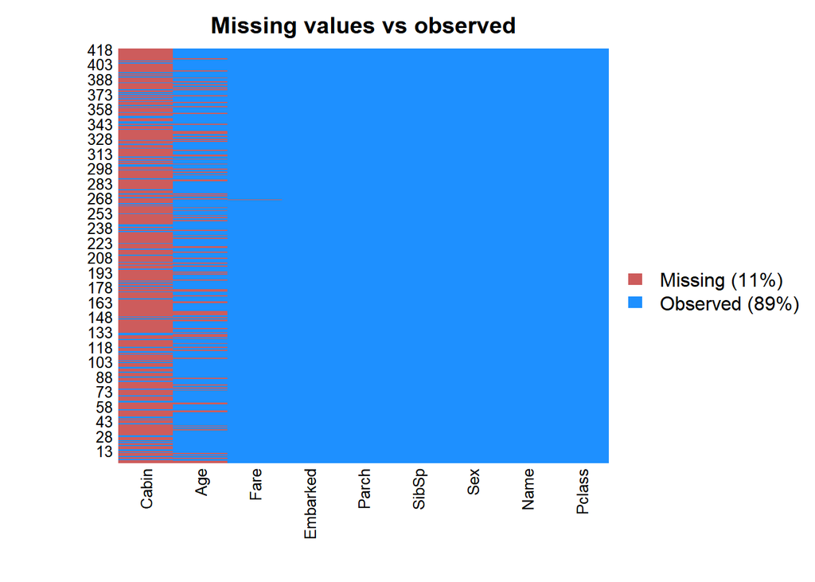

```r
# Amelia software package.
library(Amelia)
# missmap function for
missmap(Test, main = "Missing values vs observed")
```

En el gràfic observem com la variable **Cabin** es troba fortament afectada per la presència de valors NA i optem per la seva supressió directa tal i com hem fet en el fitxer anterior.

La variable **Age** també es troba afectada per la presència de valors NA que intentarem reemplaçar per la mitja o bé knn.

La variable **Fare** es troba molt poc afectada per la presència de valors NA i procedirem a la supressió de les files en les observacions que els contenen.

**Supressió de la variable Cabin i Name;**

```r
# Variable names display.
names(Test)
```

```
## [1] "Pclass"   "Name"     "Sex"      "Age"      "SibSp"    "Parch"
## [7] "Fare"     "Cabin"    "Embarked"
```

```r
# Supressing Cabin and Name variable.
Test <- subset(Test, select=c(1,3,4,5,6,7,9))
```

Suprimim aquí la variable Name perquè inicialment ens ha estat útil en la identificació de duplicats innecessaris.

```r
# Train variable names display.
names(Test)
```

```
## [1] "Pclass"   "Sex"      "Age"      "SibSp"    "Parch"    "Fare"
## [7] "Embarked"
```

**Reemplaçament de valors NA per la mitja:**

```r
# Deleting NA values from Age variable.
Test$Age[is.na(Test$Age)] <- mean(Test$Age, na.rm = T)
```

**Supressió de les files de la variable Fare amb valors NA:**

```r
# Deleting Embarked rows with NA values.
Test <- Test[!is.na(Test$Fare),]
rownames(Test) <- NULL
```

## 2.3 Valors atípics: presència d’outliers.

Variable edat:

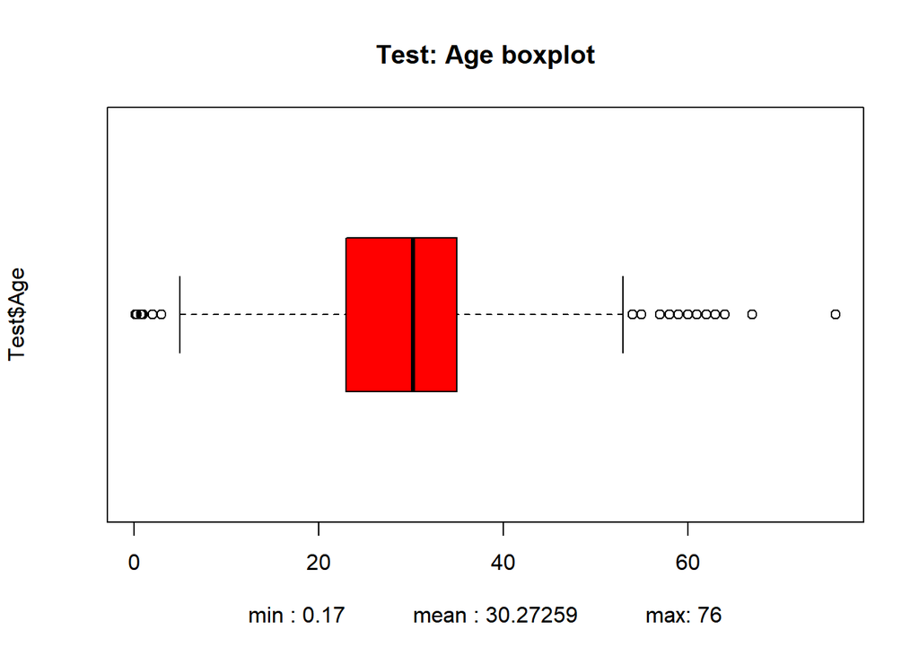

```r
# Age boxplot with outlier displaying.
boxplot(Test$Age, horizontal=TRUE, main="Test: Age boxplot", xlab="min : 0.17           mean : 30.27259           max: 76", ylab="Test$Age", col='red')
```

Variable Fare:

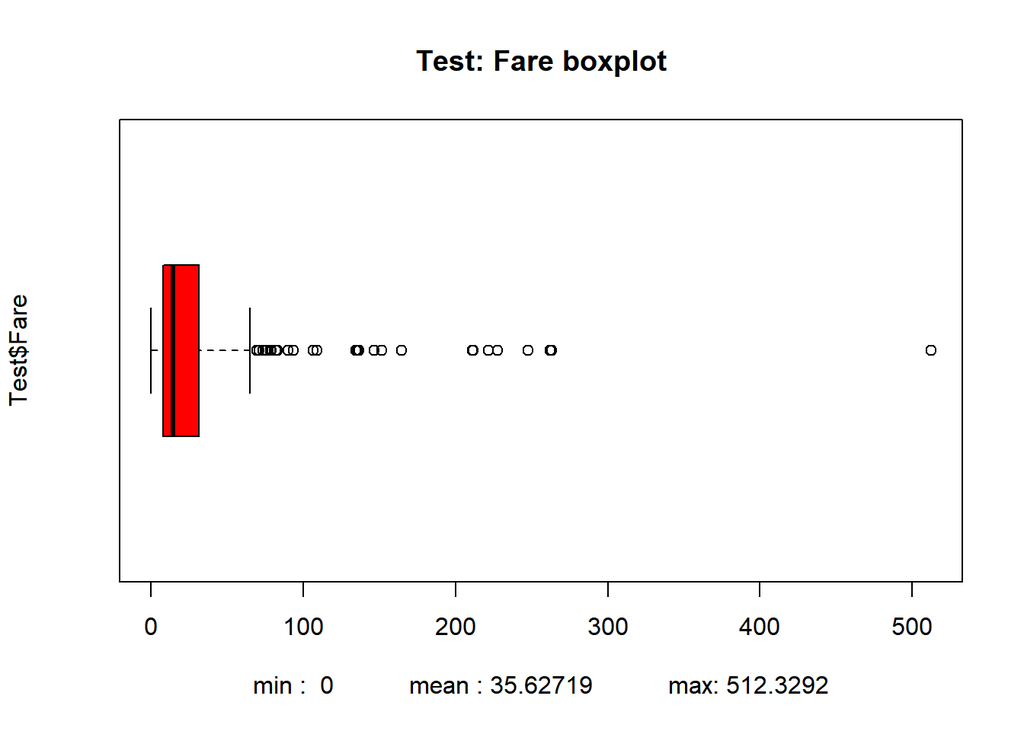

```r
# Fare boxplot with outlier displaying.
boxplot(test$Fare, horizontal=TRUE, main="Test: Fare boxplot", xlab="min :  0           mean : 35.62719           max: 512.3292", ylab="Test$Fare", col='red')
```

# 3 Consistència en les dades.

## 3.1 Valoració dels outliers en els intervals.

```r
# Statistical summary for age variable in test dataset.

numSummary(test[,"Age", drop=FALSE],
  statistics=c("mean", "sd", "IQR", "quantiles"),
  quantiles=c(0,.25,.5,.75,1))
```

```
##      mean       sd IQR   0% 25% 50% 75% 100%   n NA
##  30.27259 14.18121  18 0.17  21  27  39   76 332 86
```

Ja hem comentat que els registres anteriors en l’edat, encara que hi hagi valors considerats atípics, aquests errors no es deuen cap anotació errònia sinó que són reflexe de la realitat i en principi no suprimirem.

```r
# Statistical summary for Fare variable in test dataset.

numSummary(test[,"Fare", drop=FALSE],
  statistics=c("mean", "sd", "IQR", "quantiles"),
  quantiles=c(0,.25,.5,.75,1))
```

```
##      mean       sd     IQR 0%    25%     50%  75%     100%   n NA
##  35.62719 55.90758 23.6042  0 7.8958 14.4542 31.5 512.3292 417  1
```

La distribució de la riquesa no és equitativa, i aquesta es concentra en poques mans, de manera que hi ha bitllets en una categoria de luxe, prop d’una quarantena que resulten desorbitats en el preu i que no suprimirem.

## 3.2 Valoració de la validesa de les categories.

```r
# Travel class balance.
table(Test$Pclass)
```

```
##
##   1   2   3
## 107  93 217
```

```r
contrasts(Test$Pclass)
```

```
##   2 3
## 1 0 0
## 2 1 0
## 3 0 1
```

Hi ha tres tipus de categories de viatge en funció de l’estatus socio-econòmic, la de classe alta que respon al valor 1, classe mitja que respon al valor 2 i classe baixa que respon al valor 3, en una funció de densitat similar a la del fitxer Train.

```r
# Gender balance.
table(Test$Sex)
```

```
##
## female   male
##    152    265
```

```r
contrasts(Test$Sex)
```

```
##        male
## female    0
## male      1
```

La variable sexe presenta dues categories la female(dones) representades per el valor 0 i la male (homes) representants en valor 1, en una distribució de densitat similar a la del fitxer Train.

```r
# familiar relationships: brothers&sisters, husbands and wifes.
table(Test$SibSp)
```

```
##
##   0   1   2   3   4   5   8
## 282 110  14   4   4   1   2
```

```r
contrasts(Test$SibSp)
```

```
##   1 2 3 4 5 8
## 0 0 0 0 0 0 0
## 1 1 0 0 0 0 0
## 2 0 1 0 0 0 0
## 3 0 0 1 0 0 0
## 4 0 0 0 1 0 0
## 5 0 0 0 0 1 0
## 8 0 0 0 0 0 1
```

La variable SibSp respon al nombre de relacions abord que disposa l’individu en quant a nombres de germans, germanastres o bé cònjugues.

En el factor igual a zero indentifiquem individus que no tenen cap tipus de relació d’aquest tipus abord.

La variable SibSp en la funció de densitat mostra un comportament similar a la variable SibSP en el fitxer Train guardant una proporcionalitat.

```r
# familiar relationships: mother, father, children, son, daughter.
table(Test$Parch)
```

```
##
##   0   1   2   3   4   5   6   9
## 323  52  33   3   2   1   1   2
```

```r
contrasts(Test$Parch)
```

```
##   1 2 3 4 5 6 9
## 0 0 0 0 0 0 0 0
## 1 1 0 0 0 0 0 0
## 2 0 1 0 0 0 0 0
## 3 0 0 1 0 0 0 0
## 4 0 0 0 1 0 0 0
## 5 0 0 0 0 1 0 0
## 6 0 0 0 0 0 1 0
## 9 0 0 0 0 0 0 1
```

La variable Parch identifica el nombre de relacions famliars de progenitors o descendents abord.

Per un valor a 0 s’entén que l’individu no té cap tipus de relació d’aquest tipus abord.

```r
# Origin city embarkment balance.
table(Test$Embarked)
```

```
##
##   C   Q   S
## 102  46 269
```

```r
contrasts(Test$Embarked)
```

```
##   Q S
## C 0 0
## Q 1 0
## S 0 1
```

Hi ha tres port d’origen en els quan embarquen els passatgers C = Cherbourg, Q = Queenstown i S = Southampton.

# 4 Dataset per a la prova analítica Test:

## 4.1 Dataset Test_T.

```r
# Saving and integrated and cleaned data as Train_T.csv file
write.csv(Test, file="Test_T.csv")
```

# 5 Webgrafia